# Shiny Application and Reproducible Pitch

30 maggio 2018

## Overview

This peer assessed assignment has two parts. First, creation of a Shiny application and deployment on Rstudio's servers. Second, a Rstudio presentation about your application.

The shiny application is available [here](https://noldem.shinyapps.io/myApp/)

The github repository with source code is available [here](https://github.com/FrancescoCanuto/shinyapp)

## Application descritption

Tha application is developed using shiny. It provides the annual cost of owneship of a selecting some car features.

First, it requires you provide an estimation of your mileage per year [Milage per year input box] and the cost of fuel [Dollars per gallon].

Second, you have to input power of your vehicle [Engine Power]

Selction of type of transmission [Type of transmission] and Type of engine] are optional and not mandatory

As soon you have inputed your data, a regression model estimate your mpg (black point in the chart) and estimate total cost of ownership per year.

## mtcars dataset

The dataset is the Motor Trend Car Road Tests present in R

```r
head(mtcars)
```

```
##                    mpg cyl disp  hp drat    wt  qsec vs am gear carb
## Mazda RX4         21.0   6  160 110 3.90 2.620 16.46  0  1    4    4
## Mazda RX4 Wag     21.0   6  160 110 3.90 2.875 17.02  0  1    4    4
## Datsun 710        22.8   4  108  93 3.85 2.320 18.61  1  1    4    1
## Hornet 4 Drive    21.4   6  258 110 3.08 3.215 19.44  1  0    3    1
## Hornet Sportabout 18.7   8  360 175 3.15 3.440 17.02  0  0    3    2
## Valiant           18.1   6  225 105 2.76 3.460 20.22  1  0    3    1
```

## the plot

The regression model with mpg estimation

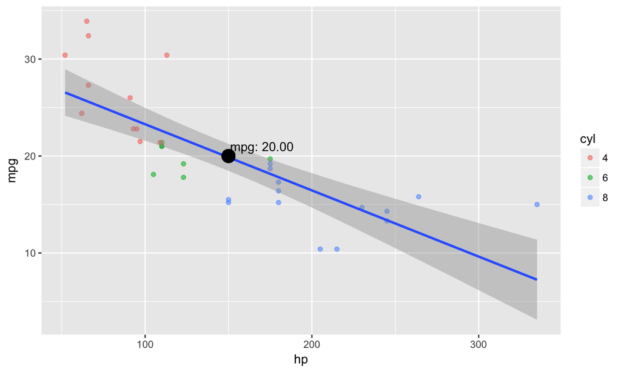